# **Market Basket Analysis/Optimization in Python using Apriori Algorithm - Building a Recommendation Engine Logic** 🍎 🍞

> **What is market basket analysis?**

Market basket analysis is a data mining technique used by retailers to increase sales by better understanding customer purchasing patterns. It involves analyzing large data sets, such as purchase history, to reveal product groupings, as well as products that are likely to be purchased together.

> **Examples of market basket analysis**

The Amazon website employs a well-known example of market basket analysis. On a product page, Amazon presents users with related products, under the headings of “Frequently bought together” and “Customers who bought this item also bought.”

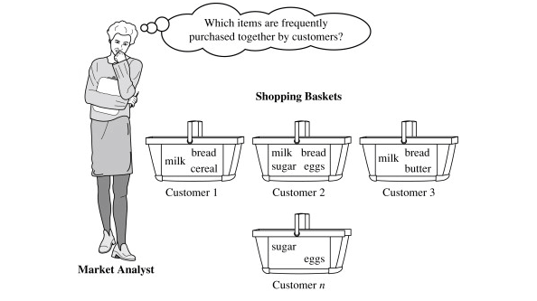

> **Overview**

Apriori is a popular algorithm for extracting frequent itemsets with applications in association rule learning. The apriori algorithm has been designed to operate on databases containing transactions, such as purchases by customers of a store. An itemset is considered as "frequent" if it meets a user-specified support threshold. For instance, if the support threshold is set to 0.5 (50%), a frequent itemset is defined as a set of items that occur together in at least 50% of all transactions in the database.

> **What is association rule mining?**

Association rule mining is the technique used to unveil the association between items, where the items we purchase are denoted as X->Y

Here X is the item we buy and Y is the item we most likely to buy (More like if->then) it is also called as

X- Antecedent

Y- Consequent

Association rule mining helps in designing the rules for the association of items. These rules are formed with the help of three terminologies

> 1.Support:

It signifies the popularity of the item, if an item is less frequently bought then it will be ignored in the association.

> 2.Confidence:

It tells the likelihood of purchasing Y when X is bought.Sounds more like a conditional probability. Infact it is ! But it fails to check the popularity(frequency) of Y to overcome that we got lift.

> 3.Lift:

It combines both confidence and support.A lift greater than 1 suggests that the presence of the antecedent increases the chances that the consequent will occur in a given transaction. Lift below 1 indicates that purchasing the antecedent reduces the chances of purchasing the consequent in the same transaction.

> For example:

Assume there are 100 customers where 10 of them bought milk, 8 bought butter and 6 bought both of them. We need to check the association of bought milk => bought butter

support = P(Milk & Butter) = 6/100 = 0.06

> **Market Basket Analysis using the Apriori method**

Apriori algorithm uses frequent itemsets to get association rules,but on the assumptions that

1. All subsets of frequent itemsets must be frequent
2. Similarly incase of infrequent subset their parent set is infrequent too The algorithm works in such a way that a minimum support value is set and iterations happen with frequent itemsets. Itemsets and subsets are ignored if their support is below the threshold till there can’t be any removal.

**Later lift of these selected itemsets(rules) are calculated and if the value is below the threshold the rules are eliminated since algorithm may take time to compile if we take all rules**

We need to import the required libraries. Python provides the apyori as an API which needs to be imported to run the apriori algorithm.

```python
pip install apriori
```

```python
pip install apyori
```

**Providing Dry Run with below Example:**

Example list of Items in each transaction are given below:

```python
T = [['A','B','C'],['A','C'],['A','D'],['B','E','F']]
T
```

```
[['A', 'B', 'C'], ['A', 'C'], ['A', 'D'], ['B', 'E', 'F']]
```

Define the rules:

Now once we are ready with the list of items in our training set, we need to run the apriori algorithm which will learn the list of association rules from the training set. Minimum support is set as 0.5, you can set it to the number you want for the items to occur that times minimum per day.

We are looking for a 50% confidence in the association rule so we have kept 0.5 as the minimum confidence. The minimum lift is taken as 1.1 and the minimum length is considered as 2 because we want to find an association between a minimum of two items. These hyperparameters can be tuned depending on the business requirements.

```python
# Training Apriori algorithm on the dataset
from apyori import apriori
rules = apriori(T,min_support = 0.5,min_confidence=0.5, min_lift=1.1,min_length=2)
```

After executing the above line of code, we have generated the list of association rules between the items of the retail. To see these rules, the below line of code needs to be executed.

```python
list(rules)
```

```
[RelationRecord(items=frozenset({'A', 'C'}), support=0.5, ordered_statistics=[OrderedStatistic(items_base=frozenset({'A'}), items_add=frozenset({'C'}), confidence=0.6666666666666666, lift=1.3333333333333333), OrderedStatistic(items_base=frozenset({'C'}), items_add=frozenset({'A'}), confidence=1.0, l…
```

> **Deducing results:**

Frozen Set shows us the items that occur together in basket for given support.

**Also, base set denotes the item that is already there, and add set denotes the item that will be added in basket further on, and bought, and confidence and lift for the same is shown.**

More the statistics value of confidence, lift, more the chances of that basket set to be bought together and hence that set should be recommended more to user.

> **More Examples:**

Python and it's libraries like numpy, pandas are generally used in Data Mining, Anlaysis, preprocessing, cleaning functionality. Follow through notebook to get understanding for same.

We can use matplotlib to visualize the results obtained from analysis

```python
#Importing required libraries
import numpy as np
import pandas as pd
```

> **Import Dataset (Data Preprocessing)**

Data preprocessing is a data mining technique which is used to transform the raw data in a useful and efficient format.

```python
# Data Preprocessing
#Pandas will be used extensively here
df = pd.read_csv("Downloads/market_basket_transactions.csv",sep='\t')
df
```

|  | Items |
| --- | --- |
| 0 | MILK,BREAD,BISCUIT |
| 1 | BREAD,MILK,BISCUIT,CORNFLAKES |
| 2 | BREAD,TEA,BOURNVITA |
| 3 | JAM,MAGGI,BREAD,MILK |
| 4 | MAGGI,TEA,BISCUIT |
| 5 | BREAD,TEA,BOURNVITA |
| 6 | MAGGI,TEA,CORNFLAKES |
| 7 | MAGGI,BREAD,TEA,BISCUIT |
| 8 | JAM,MAGGI,BREAD,TEA |
| 9 | BREAD,MILK |
| 10 | COFFEE,COCK,BISCUIT,CORNFLAKES |
| 11 | COFFEE,COCK,BISCUIT,CORNFLAKES |
| 12 | COFFEE,SUGER,BOURNVITA |
| 13 | BREAD,COFFEE,COCK |
| 14 | BREAD,SUGER,BISCUIT |
| 15 | COFFEE,SUGER,CORNFLAKES |
| 16 | BREAD,SUGER,BOURNVITA |
| 17 | BREAD,COFFEE,SUGER |
| 18 | BREAD,COFFEE,SUGER |
| 19 | TEA,MILK,COFFEE,CORNFLAKES |

> **Perform Data Cleaning:**

The data can have many irrelevant and missing parts. To handle this part, data cleaning is done. It involves handling of missing data, noisy data etc.

Below pandas function helps in telling if any row row contains null value or not. Returns true, if null value is present.

```python
df.isnull()
```

|  | Items |
| --- | --- |
| 0 | False |
| 1 | False |
| 2 | False |
| 3 | False |
| 4 | False |
| 5 | False |
| 6 | False |
| 7 | False |
| 8 | False |
| 9 | False |
| 10 | False |
| 11 | False |
| 12 | False |
| 13 | False |
| 14 | False |
| 15 | False |
| 16 | False |
| 17 | False |
| 18 | False |
| 19 | False |

Once we have read the dataset, we need to get the list of items in each transaction.

```python
df.values.tolist()
```

```
[['MILK,BREAD,BISCUIT'],
 ['BREAD,MILK,BISCUIT,CORNFLAKES'],
 ['BREAD,TEA,BOURNVITA'],
 ['JAM,MAGGI,BREAD,MILK'],
 ['MAGGI,TEA,BISCUIT'],
 ['BREAD,TEA,BOURNVITA'],
 ['MAGGI,TEA,CORNFLAKES'],
 ['MAGGI,BREAD,TEA,BISCUIT'],
 ['JAM,MAGGI,BREAD,TEA'],
 ['BREAD,MILK'],
 ['COFFEE,COCK,BISCUIT,CORNFLAKES'],
 ['COFFEE,COCK,BISCUIT,CORNFLAKES'],
 ['COFFEE,SUGER,BOURNVITA'],
 ['BREAD,COFFEE,COCK'],
 ['BREAD,SUGER,BISCUIT'],
 ['COFFEE,SUGER,CORNFLAKES'],
 ['BREAD,SUGER,BOURNVITA'],
 ['BREAD,COFFEE,SUGER'],
 ['BREAD,COFFEE,SUGER'],
 ['TEA,MILK,COFFEE,CORNFLAKES']]
```

```python
df1_transposed = df.T # or df1.transpose()
df1_transposed
```

|  | 0 | 1 | 2 | 3 | 4 | 5 | 6 | 7 | 8 | 9 | 10 | 11 | 12 | 13 | 14 | 15 | 16 | 17 | 18 | 19 |
| --- | --- | --- | --- | --- | --- | --- | --- | --- | --- | --- | --- | --- | --- | --- | --- | --- | --- | --- | --- | --- |
| Items | MILK,BREAD,BISCUIT | BREAD,MILK,BISCUIT,CORNFLAKES | BREAD,TEA,BOURNVITA | JAM,MAGGI,BREAD,MILK | MAGGI,TEA,BISCUIT | BREAD,TEA,BOURNVITA | MAGGI,TEA,CORNFLAKES | MAGGI,BREAD,TEA,BISCUIT | JAM,MAGGI,BREAD,TEA | BREAD,MILK | COFFEE,COCK,BISCUIT,CORNFLAKES | COFFEE,COCK,BISCUIT,CORNFLAKES | COFFEE,SUGER,BOURNVITA | BREAD,COFFEE,COCK | BREAD,SUGER,BISCUIT | COFFEE,SUGER,CORNFLAKES | BREAD,SUGER,BOURNVITA | BREAD,COFFEE,SUGER | BREAD,COFFEE,SUGER | TEA,MILK,COFFEE,CORNFLAKES |

We will run two loops here. One for the total number of transactions, and other for the total number of columns in each transaction. This list will work as a training set from where we can generate the list of association rules.

```python
# list with each item representing a column
ls = []
for col in df1_transposed.columns:

    col_ls = df1_transposed[col].tolist()
    str1 = ""
    for ele in col_ls:
        str1 += ele

    temp = str1.split (",")
    ls.append(temp)

print(ls)
```

```
[['MILK', 'BREAD', 'BISCUIT'], ['BREAD', 'MILK', 'BISCUIT', 'CORNFLAKES'], ['BREAD', 'TEA', 'BOURNVITA'], ['JAM', 'MAGGI', 'BREAD', 'MILK'], ['MAGGI', 'TEA', 'BISCUIT'], ['BREAD', 'TEA', 'BOURNVITA'], ['MAGGI', 'TEA', 'CORNFLAKES'], ['MAGGI', 'BREAD', 'TEA', 'BISCUIT'], ['JAM', 'MAGGI', 'BREAD', 'TE…
```

**Define the rules:**

Now once we are ready with the list of items in our training set, we need to run the apriori algorithm which will learn the list of association rules from the training set. Minimum support is set as 0.03, you can set it to the number you want for the items to occur that times minimum per day.

We are looking for a 35% confidence in the association rule so we have kept 0.35 as the minimum confidence. The minimum lift is taken as 3 and the minimum length is considered as 2 because we want to find an association between a minimum of two items. These hyperparameters can be tuned depending on the business requirements.

```python
from apyori import apriori
rules = apriori(ls,min_support = 0.03,min_confidence=0.35, min_lift=3,min_length=2)
results = list(rules)
```

```python
list(rules)
```

[output not shown]

**After executing the above line of code, we have generated the list of association rules between the items of the retail.**

**To see these rules, the below line of code needs to be executed.**

```python
# Visualizing the list of rules

for i in results:
    print('\n')
    print(i)
    print('**********')
```

```
RelationRecord(items=frozenset({'MAGGI', 'JAM'}), support=0.1, ordered_statistics=[OrderedStatistic(items_base=frozenset({'JAM'}), items_add=frozenset({'MAGGI'}), confidence=1.0, lift=4.0), OrderedStatistic(items_base=frozenset({'MAGGI'}), items_add=frozenset({'JAM'}), confidence=0.4, lift=4.0)])
**********


RelationRecord(items=frozenset({'COFFEE', 'BISCUIT', 'COCK'}), support=0.1, ordered_statistics=[OrderedStatistic(items_base=frozenset({'COCK'}), items_add=frozenset({'BISCUIT', 'COFFEE'}), confidence=0.6666666666666667, lift=6.666666666666667), OrderedStatistic(items_base=frozenset({'BISCUIT', 'COFF…
**********


RelationRecord(items=frozenset({'CORNFLAKES', 'BISCUIT', 'COCK'}), support=0.1, ordered_statistics=[OrderedStatistic(items_base=frozenset({'COCK'}), items_add=frozenset({'CORNFLAKES', 'BISCUIT'}), confidence=0.6666666666666667, lift=4.4444444444444455), OrderedStatistic(items_base=frozenset({'BISCUI…
**********


RelationRecord(items=frozenset({'CORNFLAKES', 'BISCUIT', 'COFFEE'}), support=0.1, ordered_statistics=[OrderedStatistic(items_base=frozenset({'BISCUIT', 'COFFEE'}), items_add=frozenset({'CORNFLAKES'}), confidence=1.0, lift=3.3333333333333335)])
**********


RelationRecord(items=frozenset({'TEA', 'BISCUIT', 'MAGGI'}), support=0.1, ordered_statistics=[OrderedStatistic(items_base=frozenset({'MAGGI'}), items_add=frozenset({'TEA', 'BISCUIT'}), confidence=0.4, lift=4.0), OrderedStatistic(items_base=frozenset({'TEA', 'BISCUIT'}), items_add=frozenset({'MAGGI'}…
**********


RelationRecord(items=frozenset({'SUGER', 'COFFEE', 'BOURNVITA'}), support=0.05, ordered_statistics=[OrderedStatistic(items_base=frozenset({'COFFEE', 'BOURNVITA'}), items_add=frozenset({'SUGER'}), confidence=1.0, lift=3.3333333333333335)])
**********


RelationRecord(items=frozenset({'CORNFLAKES', 'MILK', 'BREAD'}), support=0.05, ordered_statistics=[OrderedStatistic(items_base=frozenset({'CORNFLAKES', 'BREAD'}), items_add=frozenset({'MILK'}), confidence=1.0, lift=4.0)])
**********


RelationRecord(items=frozenset({'MAGGI', 'JAM', 'BREAD'}), support=0.1, ordered_statistics=[OrderedStatistic(items_base=frozenset({'JAM'}), items_add=frozenset({'MAGGI', 'BREAD'}), confidence=1.0, lift=6.666666666666667), OrderedStatistic(items_base=frozenset({'MAGGI'}), items_add=frozenset({'JAM', …
**********


RelationRecord(items=frozenset({'CORNFLAKES', 'COFFEE', 'COCK'}), support=0.1, ordered_statistics=[OrderedStatistic(items_base=frozenset({'COCK'}), items_add=frozenset({'CORNFLAKES', 'COFFEE'}), confidence=0.6666666666666667, lift=3.3333333333333335), OrderedStatistic(items_base=frozenset({'CORNFLAK…
**********


RelationRecord(items=frozenset({'CORNFLAKES', 'MILK', 'COFFEE'}), support=0.05, ordered_statistics=[OrderedStatistic(items_base=frozenset({'MILK', 'COFFEE'}), items_add=frozenset({'CORNFLAKES'}), confidence=1.0, lift=3.3333333333333335)])
**********


```

[output cut: 27 more lines]

```

RelationRecord(items=frozenset({'CORNFLAKES', 'COFFEE', 'BISCUIT', 'COCK'}), support=0.1, ordered_statistics=[OrderedStatistic(items_base=frozenset({'COCK'}), items_add=frozenset({'CORNFLAKES', 'BISCUIT', 'COFFEE'}), confidence=0.6666666666666667, lift=6.666666666666667), OrderedStatistic(items_base…
**********


RelationRecord(items=frozenset({'MILK', 'MAGGI', 'JAM', 'BREAD'}), support=0.05, ordered_statistics=[OrderedStatistic(items_base=frozenset({'JAM'}), items_add=frozenset({'MILK', 'MAGGI', 'BREAD'}), confidence=0.5, lift=10.0), OrderedStatistic(items_base=frozenset({'JAM', 'BREAD'}), items_add=frozens…
**********


RelationRecord(items=frozenset({'TEA', 'MAGGI', 'JAM', 'BREAD'}), support=0.05, ordered_statistics=[OrderedStatistic(items_base=frozenset({'JAM'}), items_add=frozenset({'TEA', 'MAGGI', 'BREAD'}), confidence=0.5, lift=5.0), OrderedStatistic(items_base=frozenset({'TEA', 'JAM'}), items_add=frozenset({'…
**********


RelationRecord(items=frozenset({'CORNFLAKES', 'MILK', 'TEA', 'COFFEE'}), support=0.05, ordered_statistics=[OrderedStatistic(items_base=frozenset({'MILK', 'COFFEE'}), items_add=frozenset({'CORNFLAKES', 'TEA'}), confidence=1.0, lift=10.0), OrderedStatistic(items_base=frozenset({'TEA', 'COFFEE'}), item…
**********
```

> **Deducing results:**

Frozen Set shows us the items that occur together in basket for given support.

**Also, base set denotes the item that is already there, and add set denotes the item that will be added in basket further on, and bought, and confidence and lift for the same is shown.**

More the statistics value of confidence, lift, more the chances of that basket set to be bought together and hence that set should be recommended more to user.

> **More Examples:**

```python
# Importing the libraries
import numpy as np
import matplotlib.pyplot as plt
import pandas as pd
```

> **Import Dataset (Data Preprocessing)**

Data preprocessing is a data mining technique which is used to transform the raw data in a useful and efficient format.

```python
# Data Preprocessing
dataset = pd.read_csv('/content/Market_Basket_Optimisation.csv', header = None)
```

```python
#display dataset
dataset
```

|  | 0 | 1 | 2 | 3 | 4 | 5 | 6 | 7 | 8 | 9 | 10 | 11 | 12 | 13 | 14 | 15 | 16 | 17 | 18 | 19 |
| --- | --- | --- | --- | --- | --- | --- | --- | --- | --- | --- | --- | --- | --- | --- | --- | --- | --- | --- | --- | --- |
| 0 | shrimp | almonds | avocado | vegetables mix | green grapes | whole weat flour | yams | cottage cheese | energy drink | tomato juice | low fat yogurt | green tea | honey | salad | mineral water | salmon | antioxydant juice | frozen smoothie | spinach | olive oil |
| 1 | burgers | meatballs | eggs | NaN | NaN | NaN | NaN | NaN | NaN | NaN | NaN | NaN | NaN | NaN | NaN | NaN | NaN | NaN | NaN | NaN |
| 2 | chutney | NaN | NaN | NaN | NaN | NaN | NaN | NaN | NaN | NaN | NaN | NaN | NaN | NaN | NaN | NaN | NaN | NaN | NaN | NaN |
| 3 | turkey | avocado | NaN | NaN | NaN | NaN | NaN | NaN | NaN | NaN | NaN | NaN | NaN | NaN | NaN | NaN | NaN | NaN | NaN | NaN |
| 4 | mineral water | milk | energy bar | whole wheat rice | green tea | NaN | NaN | NaN | NaN | NaN | NaN | NaN | NaN | NaN | NaN | NaN | NaN | NaN | NaN | NaN |
| ... | ... | ... | ... | ... | ... | ... | ... | ... | ... | ... | ... | ... | ... | ... | ... | ... | ... | ... | ... | ... |
| 7496 | butter | light mayo | fresh bread | NaN | NaN | NaN | NaN | NaN | NaN | NaN | NaN | NaN | NaN | NaN | NaN | NaN | NaN | NaN | NaN | NaN |
| 7497 | burgers | frozen vegetables | eggs | french fries | magazines | green tea | NaN | NaN | NaN | NaN | NaN | NaN | NaN | NaN | NaN | NaN | NaN | NaN | NaN | NaN |
| 7498 | chicken | NaN | NaN | NaN | NaN | NaN | NaN | NaN | NaN | NaN | NaN | NaN | NaN | NaN | NaN | NaN | NaN | NaN | NaN | NaN |
| 7499 | escalope | green tea | NaN | NaN | NaN | NaN | NaN | NaN | NaN | NaN | NaN | NaN | NaN | NaN | NaN | NaN | NaN | NaN | NaN | NaN |
| 7500 | eggs | frozen smoothie | yogurt cake | low fat yogurt | NaN | NaN | NaN | NaN | NaN | NaN | NaN | NaN | NaN | NaN | NaN | NaN | NaN | NaN | NaN | NaN |

7501 rows × 20 columns

> **Perform Data Cleaning and store it to list**

The data can have many irrelevant and missing parts. To handle this part, data cleaning is done. It involves handling of missing data, noisy data etc.

```python
#Getting the list of transactions from the dataset
#Ignoring the Null Values

T = []
for i in range(0, 7501):
    T.append([str(dataset.values[i,j]) for j in range(0, 20) if str(dataset.values[i,j])!='nan'])
```

```python
T
```

```
[['shrimp',
  'almonds',
  'avocado',
  'vegetables mix',
  'green grapes',
  'whole weat flour',
  'yams',
  'cottage cheese',
  'energy drink',
  'tomato juice',
  'low fat yogurt',
  'green tea',
  'honey',
  'salad',
  'mineral water',
  'salmon',
  'antioxydant juice',
  'frozen smoothie',
  'spinach',
  'olive oil'],
 ['burgers', 'meatballs', 'eggs'],
 ['chutney'],
 ['turkey', 'avocado'],
 ['mineral water', 'milk', 'energy bar', 'whole wheat rice', 'green tea'],
 ['low fat yogurt'],
 ['whole wheat pasta', 'french fries'],
 ['soup', 'light cream', 'shallot'],
 ['frozen vegetables', 'spaghetti', 'green tea'],
 ['french fries'],
 ['eggs', 'pet food'],
 ['cookies'],
 ['turkey', 'burgers', 'mineral water', 'eggs', 'cooking oil'],
 ['spaghetti', 'champagne', 'cookies'],
 ['mineral water', 'salmon'],
 ['mineral water'],
 ['shrimp',
  'chocolate',
  'chicken',
  'honey',
  'oil',
```

[output cut: 2705 more lines]

```
 ['frozen smoothie'],
 ['herb & pepper', 'frozen vegetables', 'mineral water', 'muffins', 'cereals'],
 ['turkey',
  'tomatoes',
  'spaghetti',
  'milk',
  'cider',
  'eggs',
  'honey',
  'cake',
  'green tea',
  'french fries',
  'brownies',
  'tomato juice'],
 ...]
```

**Define the rules:**

Now once we are ready with the list of items in our training set, we need to run the apriori algorithm which will learn the list of association rules from the training set.

```python
#Defining desired rules
from apyori import apriori
rules = apriori(T,min_support = 0.003,min_confidence=0.35, min_lift=3,min_length=2)
results = list(rules)
```

**Displaying the Resutls:**

```python
for i in results:
    print('\n')
    print(i)
    print('**********')
```

```
RelationRecord(items=frozenset({'escalope', 'pasta'}), support=0.005865884548726837, ordered_statistics=[OrderedStatistic(items_base=frozenset({'pasta'}), items_add=frozenset({'escalope'}), confidence=0.3728813559322034, lift=4.700811850163794)])
**********


RelationRecord(items=frozenset({'ground beef', 'tomato sauce'}), support=0.005332622317024397, ordered_statistics=[OrderedStatistic(items_base=frozenset({'tomato sauce'}), items_add=frozenset({'ground beef'}), confidence=0.3773584905660377, lift=3.840659481324083)])
**********


RelationRecord(items=frozenset({'avocado', 'spaghetti', 'milk'}), support=0.003332888948140248, ordered_statistics=[OrderedStatistic(items_base=frozenset({'avocado', 'spaghetti'}), items_add=frozenset({'milk'}), confidence=0.41666666666666663, lift=3.215449245541838)])
**********


RelationRecord(items=frozenset({'frozen vegetables', 'cake', 'tomatoes'}), support=0.0030662578322890282, ordered_statistics=[OrderedStatistic(items_base=frozenset({'cake', 'tomatoes'}), items_add=frozenset({'frozen vegetables'}), confidence=0.36507936507936506, lift=3.8300144300144296)])
**********


RelationRecord(items=frozenset({'cereals', 'spaghetti', 'ground beef'}), support=0.0030662578322890282, ordered_statistics=[OrderedStatistic(items_base=frozenset({'cereals', 'ground beef'}), items_add=frozenset({'spaghetti'}), confidence=0.6764705882352942, lift=3.8853031258445188), OrderedStatistic…
**********


RelationRecord(items=frozenset({'chicken', 'milk', 'ground beef'}), support=0.0038661511798426876, ordered_statistics=[OrderedStatistic(items_base=frozenset({'chicken', 'ground beef'}), items_add=frozenset({'milk'}), confidence=0.40845070422535207, lift=3.152046020981858)])
**********


RelationRecord(items=frozenset({'chicken', 'milk', 'olive oil'}), support=0.0035995200639914677, ordered_statistics=[OrderedStatistic(items_base=frozenset({'chicken', 'olive oil'}), items_add=frozenset({'milk'}), confidence=0.5, lift=3.858539094650206)])
**********


RelationRecord(items=frozenset({'ground beef', 'chocolate', 'herb & pepper'}), support=0.003999466737768298, ordered_statistics=[OrderedStatistic(items_base=frozenset({'chocolate', 'herb & pepper'}), items_add=frozenset({'ground beef'}), confidence=0.4411764705882354, lift=4.4901827759597746)])
**********


RelationRecord(items=frozenset({'milk', 'chocolate', 'soup'}), support=0.003999466737768298, ordered_statistics=[OrderedStatistic(items_base=frozenset({'chocolate', 'soup'}), items_add=frozenset({'milk'}), confidence=0.3947368421052632, lift=3.0462150747238472)])
**********


RelationRecord(items=frozenset({'ground beef', 'spaghetti', 'cooking oil'}), support=0.004799360085321957, ordered_statistics=[OrderedStatistic(items_base=frozenset({'ground beef', 'cooking oil'}), items_add=frozenset({'spaghetti'}), confidence=0.5714285714285714, lift=3.2819951870487856)])
**********


```

[output cut: 107 more lines]

```

RelationRecord(items=frozenset({'milk', 'frozen vegetables', 'mineral water', 'soup'}), support=0.0030662578322890282, ordered_statistics=[OrderedStatistic(items_base=frozenset({'frozen vegetables', 'soup'}), items_add=frozenset({'milk', 'mineral water'}), confidence=0.3833333333333333, lift=7.98717…
**********


RelationRecord(items=frozenset({'spaghetti', 'shrimp', 'frozen vegetables', 'mineral water'}), support=0.003332888948140248, ordered_statistics=[OrderedStatistic(items_base=frozenset({'spaghetti', 'shrimp', 'mineral water'}), items_add=frozenset({'frozen vegetables'}), confidence=0.39062500000000006…
**********


RelationRecord(items=frozenset({'spaghetti', 'frozen vegetables', 'mineral water', 'tomatoes'}), support=0.0030662578322890282, ordered_statistics=[OrderedStatistic(items_base=frozenset({'frozen vegetables', 'mineral water', 'tomatoes'}), items_add=frozenset({'spaghetti'}), confidence=0.522727272727…
**********


RelationRecord(items=frozenset({'ground beef', 'spaghetti', 'mineral water', 'tomatoes'}), support=0.0030662578322890282, ordered_statistics=[OrderedStatistic(items_base=frozenset({'ground beef', 'mineral water', 'tomatoes'}), items_add=frozenset({'spaghetti'}), confidence=0.5609756097560976, lift=3…
**********
```

**Take notice how various Pandas functios can be used to perform Data Analysis**

```python
#Check Max Sold Item
```

```python
D = dataset.values.ravel()
```

```python
D
```

```
array(['shrimp', 'almonds', 'avocado', ..., nan, nan, nan], dtype=object)
```

```python
import collections
val = collections.Counter(D)
val
```

```
Counter({'shrimp': 536,
         'almonds': 153,
         'avocado': 250,
         'vegetables mix': 193,
         'green grapes': 68,
         'whole weat flour': 70,
         'yams': 86,
         'cottage cheese': 239,
         'energy drink': 200,
         'tomato juice': 228,
         'low fat yogurt': 574,
         'green tea': 991,
         'honey': 356,
         'salad': 37,
         'mineral water': 1788,
         'salmon': 319,
         'antioxydant juice': 67,
         'frozen smoothie': 475,
         'spinach': 53,
         'olive oil': 494,
         'burgers': 654,
         'meatballs': 157,
         'eggs': 1348,
         nan: 120657,
         'chutney': 31,
         'turkey': 469,
         'milk': 972,
         'energy bar': 203,
         'whole wheat rice': 439,
         'whole wheat pasta': 221,
         'french fries': 1282,
         'soup': 379,
         'light cream': 117,
         'shallot': 58,
         'frozen vegetables': 715,
         'spaghetti': 1306,
         'pet food': 49,
         'cookies': 603,
         'cooking oil': 383,
         'champagne': 351,
```

[output cut: 66 more lines]

```
         'dessert wine': 33,
         'flax seed': 68,
         'hand protein bar': 39,
         'sandwich': 34,
         'babies food': 34,
         'melons': 90,
         'cauliflower': 36,
         'green beans': 65,
         'ketchup': 33,
         'bramble': 14,
         'burger sauce': 44,
         'oatmeal': 33,
         ' asparagus': 1,
         'cream': 7,
         'napkins': 5})
```

```python
val.items()
```

```
dict_items([('shrimp', 536), ('almonds', 153), ('avocado', 250), ('vegetables mix', 193), ('green grapes', 68), ('whole weat flour', 70), ('yams', 86), ('cottage cheese', 239), ('energy drink', 200), ('tomato juice', 228), ('low fat yogurt', 574), ('green tea', 991), ('honey', 356), ('salad', 37), (…
```

```python
df = pd.DataFrame(val.items())
df
```

|  | 0 | 1 |
| --- | --- | --- |
| 0 | shrimp | 536 |
| 1 | almonds | 153 |
| 2 | avocado | 250 |
| 3 | vegetables mix | 193 |
| 4 | green grapes | 68 |
| ... | ... | ... |
| 116 | burger sauce | 44 |
| 117 | oatmeal | 33 |
| 118 | asparagus | 1 |
| 119 | cream | 7 |
| 120 | napkins | 5 |

121 rows × 2 columns

```python
df = df.rename(columns={0:'Items',1:'Total'})
df
```

|  | Items | Total |
| --- | --- | --- |
| 0 | shrimp | 536 |
| 1 | almonds | 153 |
| 2 | avocado | 250 |
| 3 | vegetables mix | 193 |
| 4 | green grapes | 68 |
| ... | ... | ... |
| 116 | burger sauce | 44 |
| 117 | oatmeal | 33 |
| 118 | asparagus | 1 |
| 119 | cream | 7 |
| 120 | napkins | 5 |

121 rows × 2 columns

```python
#This gives us maximum sold items, which can be very useful in our recommendation engine logic
df.sort_values(by='Total',ascending=False)[1:]
```

|  | Items | Total |
| --- | --- | --- |
| 14 | mineral water | 1788 |
| 22 | eggs | 1348 |
| 35 | spaghetti | 1306 |
| 30 | french fries | 1282 |
| 40 | chocolate | 1230 |
| ... | ... | ... |
| 115 | bramble | 14 |
| 119 | cream | 7 |
| 120 | napkins | 5 |
| 98 | water spray | 3 |
| 118 | asparagus | 1 |

120 rows × 2 columns

> **Visualizing the results for better Understanding**

Libraries like matplotlib and Seaborn can be useful for the same

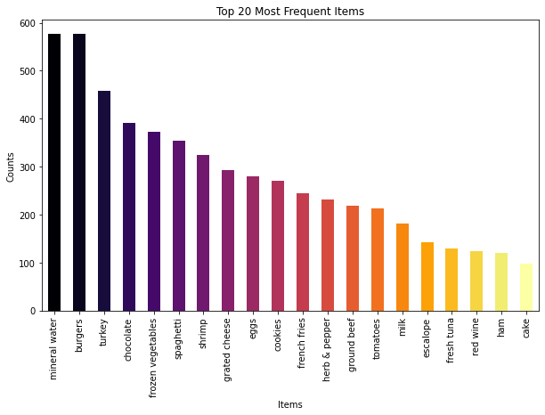

```python
#This displays top 20 most frequent items in above data set
plt.rcParams['figure.figsize'] = (10,6)
color = plt.cm.inferno(np.linspace(0,1,20))
dataset[0].value_counts().head(20).plot.bar(color = color)
plt.title('Top 20 Most Frequent Items')
plt.ylabel('Counts')
plt.xlabel('Items')
plt.show()
```

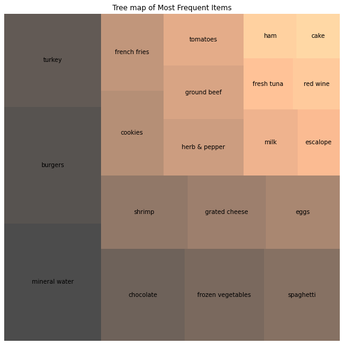

```python
# Tree Map of Most Frequent Items
import squarify
plt.rcParams['figure.figsize']=(10,10)
Items = dataset[0].value_counts().head(20).to_frame()
size = Items[0].values
lab = Items.index
color = plt.cm.copper(np.linspace(0,1,20))
squarify.plot(sizes=size, label=lab, alpha = 0.7, color=color)
plt.title('Tree map of Most Frequent Items')
plt.axis('off')
plt.show()
```

> **More Complex Example:**

```python
#for data visualization
import matplotlib.pyplot as plt
import seaborn as sns

#for performing market basket analysis
from mlxtend.frequent_patterns import apriori, association_rules
```

> **Import Dataset (Data Preprocessing)**

Data preprocessing is a data mining technique which is used to transform the raw data in a useful and efficient format.

```python
#reading data
data=pd.read_csv('/content/groceries - groceries.csv')
print(f'Shape of data: {data.shape[0]} rows and {data.shape[1]} columns')
```

```
Shape of data: 9835 rows and 33 columns
```

```python
#glance of dataset
pd.set_option('max_columns', 35)
data.head()
```

|  | Item(s) | Item 1 | Item 2 | Item 3 | Item 4 | Item 5 | Item 6 | Item 7 | Item 8 | Item 9 | Item 10 | Item 11 | Item 12 | Item 13 | Item 14 | Item 15 | Item 16 | Item 17 | Item 18 | Item 19 | Item 20 | Item 21 | Item 22 | Item 23 | Item 24 | Item 25 | Item 26 | Item 27 | Item 28 | … |
| --- | --- | --- | --- | --- | --- | --- | --- | --- | --- | --- | --- | --- | --- | --- | --- | --- | --- | --- | --- | --- | --- | --- | --- | --- | --- | --- | --- | --- | --- | --- |
| 0 | 4 | citrus fruit | semi-finished bread | margarine | ready soups | NaN | NaN | NaN | NaN | NaN | NaN | NaN | NaN | NaN | NaN | NaN | NaN | NaN | NaN | NaN | NaN | NaN | NaN | NaN | NaN | NaN | NaN | NaN | NaN | … |
| 1 | 3 | tropical fruit | yogurt | coffee | NaN | NaN | NaN | NaN | NaN | NaN | NaN | NaN | NaN | NaN | NaN | NaN | NaN | NaN | NaN | NaN | NaN | NaN | NaN | NaN | NaN | NaN | NaN | NaN | NaN | … |
| 2 | 1 | whole milk | NaN | NaN | NaN | NaN | NaN | NaN | NaN | NaN | NaN | NaN | NaN | NaN | NaN | NaN | NaN | NaN | NaN | NaN | NaN | NaN | NaN | NaN | NaN | NaN | NaN | NaN | NaN | … |
| 3 | 4 | pip fruit | yogurt | cream cheese | meat spreads | NaN | NaN | NaN | NaN | NaN | NaN | NaN | NaN | NaN | NaN | NaN | NaN | NaN | NaN | NaN | NaN | NaN | NaN | NaN | NaN | NaN | NaN | NaN | NaN | … |
| 4 | 4 | other vegetables | whole milk | condensed milk | long life bakery product | NaN | NaN | NaN | NaN | NaN | NaN | NaN | NaN | NaN | NaN | NaN | NaN | NaN | NaN | NaN | NaN | NaN | NaN | NaN | NaN | NaN | NaN | NaN | NaN | … |

> **Visualizing Top 20 frequently buying items by customer**

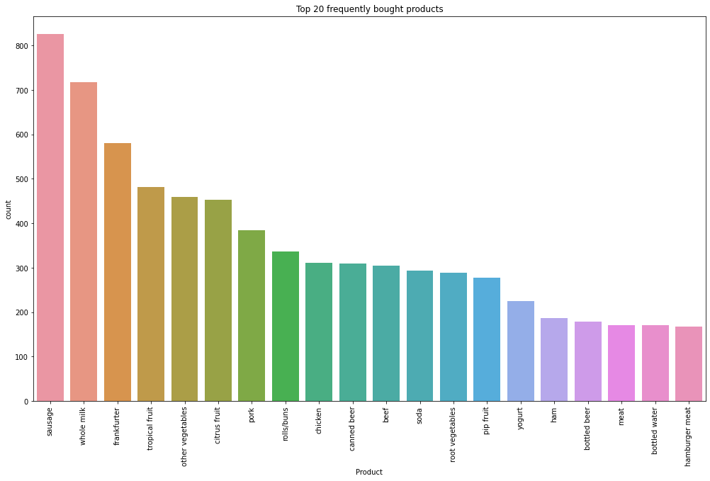

```python
plt.rcParams['figure.figsize']=17,10
sns.countplot(data=data, x=data['Item 1'],
             order = data['Item 1'].value_counts().head(20).index)
plt.xticks(rotation=90)
plt.xlabel('Product')
plt.title('Top 20 frequently bought products')
plt.show()
```

> **Store Data into list**

```python
#list of list of transaction
records = []
for i in range(0, len(data)):
    records.append([str(data.values[i,j]) for j in range(1, data.values[i, 0]+1)])
```

```python
#Let's encode the created list of list like onehot encode

from mlxtend.preprocessing import TransactionEncoder

te = TransactionEncoder()
onehot = te.fit_transform(records)
onehot = pd.DataFrame(onehot, columns = te.columns_)
```

```python
#Selecting specific items in which we are itnerested
onehot = onehot.loc[:, ['bottled beer', 'bottled water', 'brandy', 'brown bread', 'butter', 'syrup',
                    'sweet spreads', 'beverages', 'berries', 'beef', 'bathroom cleaner', 'baking powder', 'bags',
                    'baby food', 'baby cosmetics', 'Instant food products', 'tea', 'toilet cleaner', 'vinegar', 'waffles', 'whisky',
                    'white bread', 'white wine', 'yogurt', 'zwieback', 'whole milk', 'whipped/sour cream', 'abrasive cleaner']]

print(f'Shape of encoded data: {onehot.shape[0]} rows and {onehot.shape[1]} columns')
```

```
Shape of encoded data: 9835 rows and 28 columns
```

```python
#Let's generate the frequent itemset using apriori with minimum support of 0.01%
#maximum item per transaction restricted to 3

from mlxtend.frequent_patterns import apriori, association_rules

frequent_itemsets=apriori(onehot, min_support=0.0001, use_colnames=True, max_len=3)
frequent_itemsets
```

|  | support | itemsets |
| --- | --- | --- |
| 0 | 0.080529 | (bottled beer) |
| 1 | 0.110524 | (bottled water) |
| 2 | 0.004169 | (brandy) |
| 3 | 0.064870 | (brown bread) |
| 4 | 0.055414 | (butter) |
| ... | ... | ... |
| 1006 | 0.010880 | (whipped/sour cream, yogurt, whole milk) |
| 1007 | 0.000712 | (yogurt, whole milk, abrasive cleaner) |
| 1008 | 0.000102 | (whipped/sour cream, yogurt, abrasive cleaner) |
| 1009 | 0.000203 | (whipped/sour cream, zwieback, whole milk) |
| 1010 | 0.000508 | (whipped/sour cream, whole milk, abrasive clea... |

1011 rows × 2 columns

```python
#Generating Association rule with mlxtend's association_rules
rules=association_rules(frequent_itemsets)
rules.shape
```

```
(164, 9)
```

```python
#Pruning the generated rules using multiple filters

targeted_rules = rules[rules['antecedents'] == {'baby food'}].copy()
filtered_rules = targeted_rules[(targeted_rules['confidence'] > 0.85) &
                                (targeted_rules['lift'] > 1.00)]
```

> **Strength of association using heatmap:**

We can analyse how strong antecedent and consequents are related with each other by using heat map, see below example.

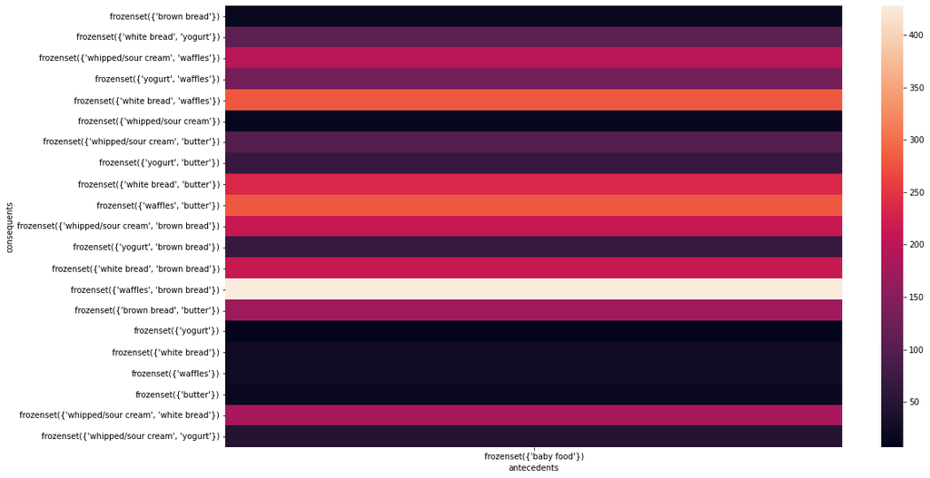

```python
#let's analyse the 'baby foods' relevent consequents

support_table = filtered_rules.pivot(index='consequents', columns='antecedents', values='lift')
sns.heatmap(support_table)
```

```python
rules['antecedent'] = rules['antecedents'].apply(lambda antecedent: list(antecedent)[0])
rules['consequent'] = rules['consequents'].apply(lambda consequent: list(consequent)[0])
rules['rule'] = rules.index
coords = rules[['antecedent','consequent','rule']]
```

> **Generate parallel coordinates plot**

Parallel coordinates plots can become very hard to interpret if there are too many lines, so use this plot style with caution. Still, it can be an interesting way to view how your items interrelate — which items have a high likelihood of leading to many other items, and which items are frequent consequents for others.

The colors of the lines are assigned in the order that pandas encounters the items. See below example.

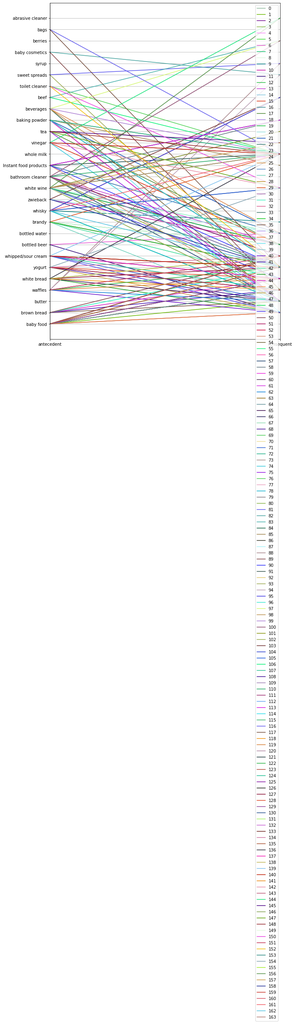

```python
# Generate parallel coordinates plot

from pandas.plotting import parallel_coordinates

plt.rcParams['figure.figsize']=10,15
parallel_coordinates(coords,'rule')
plt.show()
```

> **Conclusion:**

We performed market basket analysis wth help of apriori algorithm, and solved real-life problem. Market basket analysis can help in building recommendation engine logics, and help us analyse the buying trends of the customer, which can help the seller to recommend those items and items set, which are sold more.

We used various libraries like Pandas, Numpy to preprocess, clean our data. Apriori algo was used for performing data mining and associative rule mining analysis.

Further libraries like Matplotlib and Seaborn were used to create plots to visualize and deduce conclusions from apriori algo results.